# Lab 8. Communities

# 2 Ordinate on Species Dissimilarity

In multivariate analysis, *ordination* (eg *gradient analysis*) orders objects that are characterized by values on multiple variables (i.e., multivariate objects) so that similar objects are near each other and dissimilar objects are farther from each other. These relationships between the objects, on one or more axes, are then characterized numerically and/or graphically. Here’s a dichotomus key for choosing the appropriate ordination technique from Dean Urban’s Multivariate class:

| Question | Choice |
| --- | --- |
| 1a. Ancillary data (ENV) not available, or not used to constrain the ordination | 2 |
| 1b. Ancillary data (ENV) available and used in ordination | 4 |
| 2a. Species response assumed linear | PCA (FA) |
| 2b. Species response not linear, or unknown | 3 |
| 3a. Species response assumed nonlinear and unimodal | DCA (RA) |
| 3b. Species response not linear, nor nonlinear and unimodal, or unknown | NMS (PCoA, BC) |
| 4a. Species response assumed linear | RDA |
| 4b. Species response not linear, or unknown | 5 |
| 5a. Species response nonlinear and unimodal | 6 |
| 5b. Species response not linear, nor nonlinear and unimodal, or unknown | dbRDA |
| 6a. A single (or few) environmental factors known (or required) as constraints | DO |
| 6b. Several factors suspected | CCA |

In the key, the lead technique is the best or default choice; alternatives in parentheses are options appropriate to particular data sets (see Applications Checklist, below). The techniques:

- PCA: Principal components analysis
- FA: Factor analysis
- DCA: Detrended correspondence analysis
- RA: Reciprocal averaging
- NMS: nonmetric multidimensional scaling
- PCoA: Principal coordinates analysis
- BC: Bray-Curtis (Polar) ordination
- RDA: Redundancy analysis
- CCA: Canonical correspondence analysis
- dbRDA: distance-based RDA
- DO: Direct ordination (includes weighted averaging)

Since nonmetric multidimensional scaling has the fewest assumptions of the data, we’ll proceed with that technique.

```r
spp11_mds = metaMDS(spp11, k=3, trace=F, trymax=100)
spp11_mds
```

```
##
## Call:
## metaMDS(comm = spp11, k = 3, trymax = 100, trace = F)
##
## global Multidimensional Scaling using monoMDS
##
## Data:     wisconsin(sqrt(spp11))
## Distance: bray
##
## Dimensions: 3
## Stress:     0.07271247
## Stress type 1, weak ties
## Two convergent solutions found after 97 tries
## Scaling: centring, PC rotation, halfchange scaling
## Species: expanded scores based on 'wisconsin(sqrt(spp11))'
```

**Question** Note in the R chunk above that the data input for the `metaMDS` function is the original species composition data `sp11`, but how did the argument `k=3` and default values for arguments `distance` and `autotransform` affect the results?

Let’s look at the first 2 axis of ordination with site numbers in black and species in red.

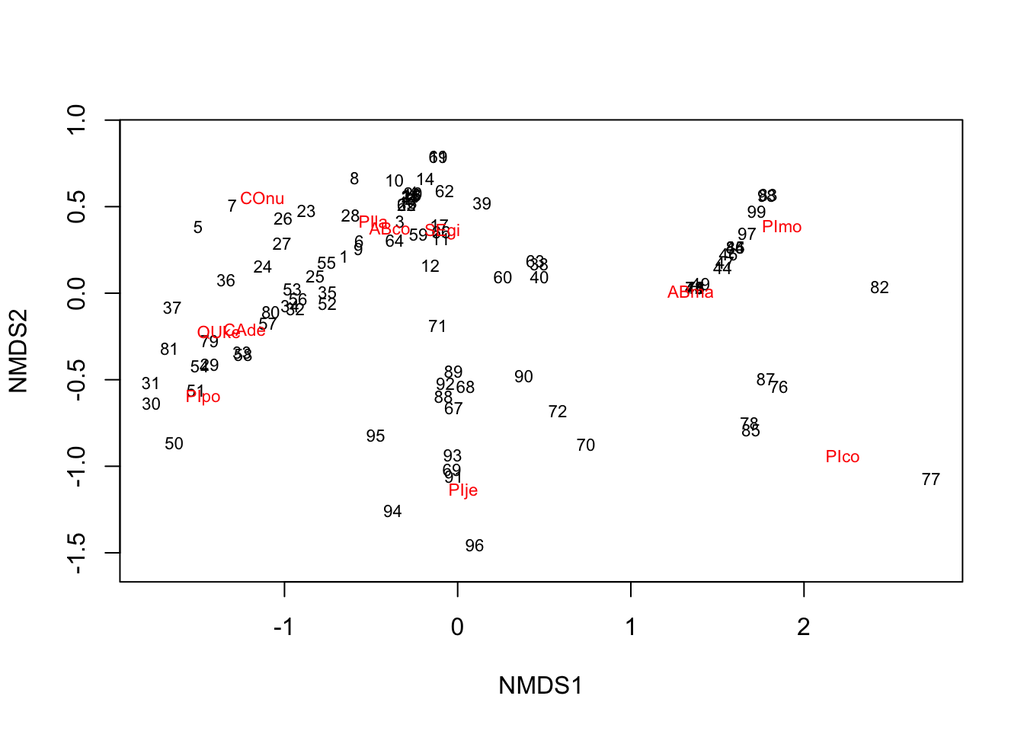

```r
plot(spp11_mds, type='t')
```

There’s a third axis which you can see in this plot.

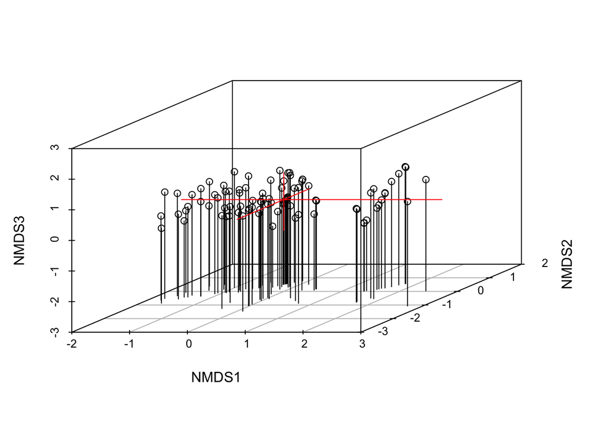

```r
ordiplot3d(spp11_mds, type='h')
```

You can also interact with a 3D plot using the following commands in the Console which opens up a new window (that you need to find in the Windows bar). Click hold and rotate the axes. First, by sites:

```r
if (interactive()){
  ordirgl(spp11_mds, size=2) # default sites
}
```

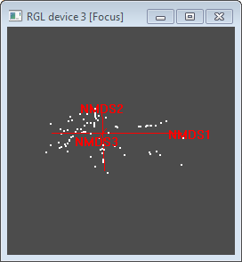

or by species:

```r
if (interactive()){
  ordirgl(spp11_mds, display='species', type='t') # species
}
```

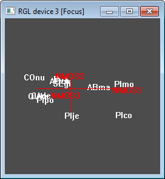

# 3 Cluster on Species Dissimilarity

Now hierarchically cluster the sites using the same transformed Bray-Curtis species dissimilarity input as the ordination.

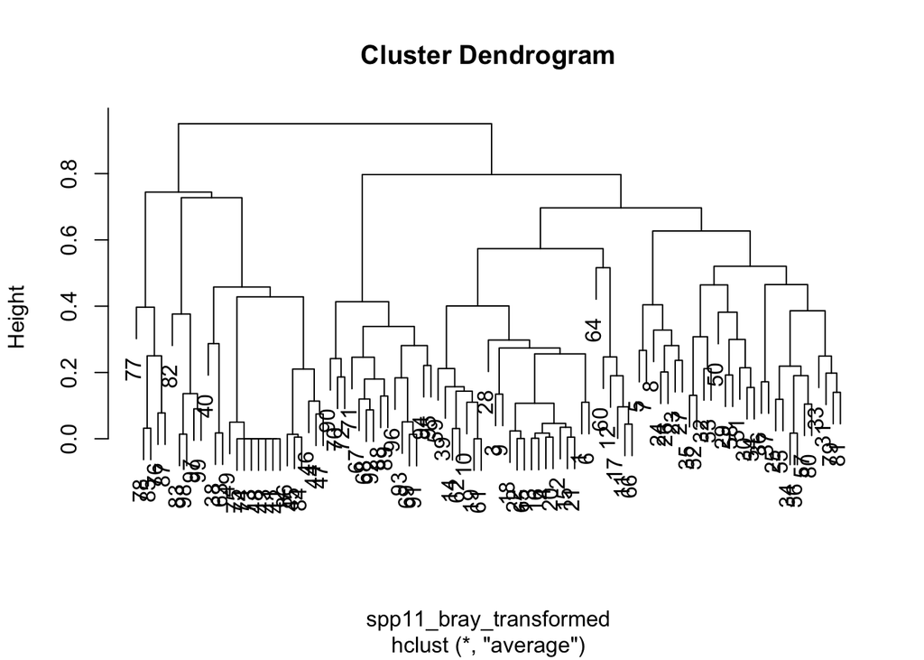

```r
# hierarchically cluster sites
clu = hclust(spp11_bray_transformed, 'average')
plot(clu)
```

Now cutoff the hierarchical cluster into three groups.

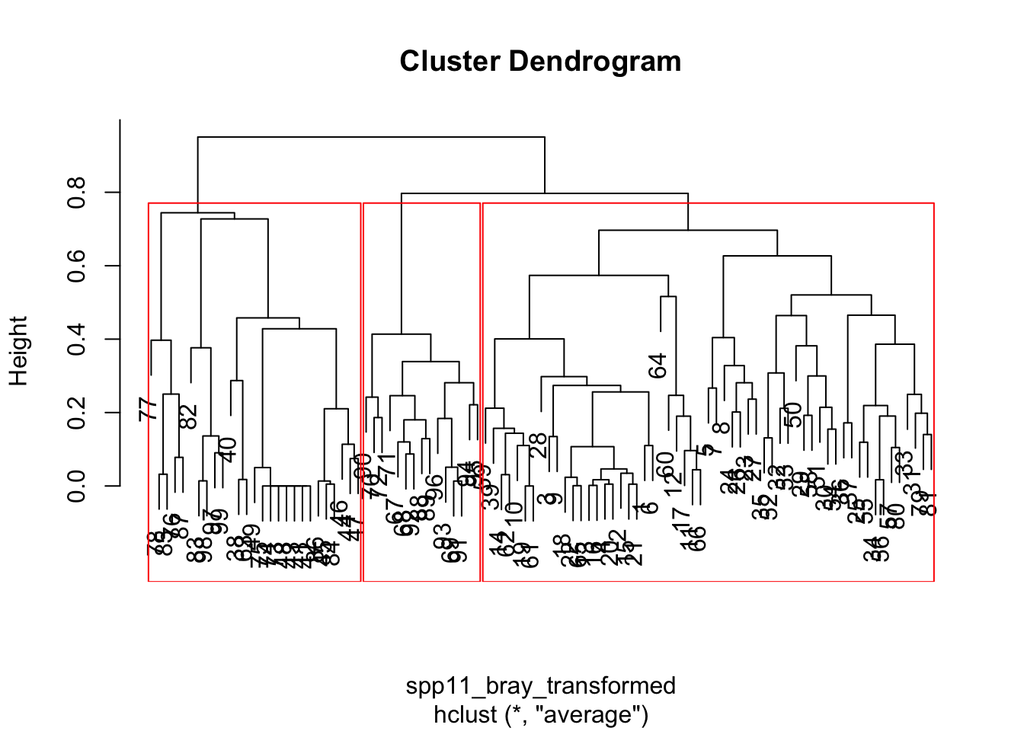

```r
# cutoff clusters to 3 groups
plot(clu)
rect.hclust(clu, k=3) # or by height of similarity h=0.5
```

```r
grp = cutree(clu, k=3)
```

Plot the groups in ordination space.

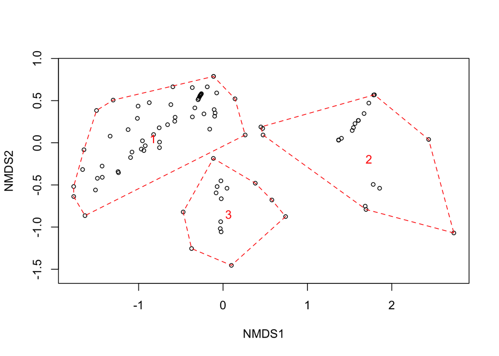

```r
# plot convex hull of groups: overlap
plot(spp11_mds, display='sites')
ordihull(spp11_mds, grp, lty=2, col='red', label=T)
```

Which you can also do interactively in 3D.

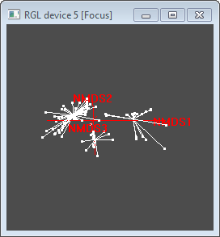

```r
if (interactive()){
  # plot 3D to see 3rd NMS axis
  ordirgl(spp11_mds, display='sites') #, type='t')
  orglspider(spp11_mds, grp)
}
```

# 4 Fit Environment into Ordination Space

Next, you’ll plot the environment vectors fitted into the “species” space.

```r
env21 = read.csv('data/env21.csv', row.names=1)
ef = envfit(spp11_mds, env21, permu = 999)
ef
```

```
##
## ***VECTORS
##
##            NMDS1    NMDS2     r2 Pr(>r)
## Elev     0.99995 -0.01038 0.8823  0.001 ***
## Slope   -0.62043  0.78426 0.0530  0.090 .
## Tasp     0.71012 -0.70408 0.0053  0.753
## TSI      0.84736 -0.53101 0.0138  0.515
## xLitter -0.49325  0.86989 0.0503  0.068 .
## xDepth  -0.60080  0.79940 0.4012  0.001 ***
## sDepth   0.72877  0.68476 0.0089  0.668
## pH      -0.55792  0.82989 0.5088  0.001 ***
## C        0.58942 -0.80783 0.1307  0.001 ***
## N        0.33071 -0.94373 0.0704  0.026 *
## CN       0.99981 -0.01968 0.2649  0.001 ***
## P       -0.09770  0.99522 0.0556  0.066 .
## Ca      -0.86190  0.50709 0.2417  0.001 ***
## Mg      -0.99148 -0.13023 0.2255  0.001 ***
## K       -0.93975  0.34186 0.2126  0.001 ***
## Acid     0.76256 -0.64691 0.5098  0.001 ***
## ECEC    -0.93377  0.35787 0.1705  0.001 ***
## BS      -0.85626  0.51654 0.5999  0.001 ***
## Clay    -0.35055 -0.93654 0.0267  0.259
## Silt    -0.25389 -0.96723 0.0030  0.863
## Sand     0.26003  0.96560 0.0048  0.785
## ---
## Signif. codes:  0 '***' 0.001 '**' 0.01 '*' 0.05 '.' 0.1 ' ' 1
## Permutation: free
## Number of permutations: 999
```

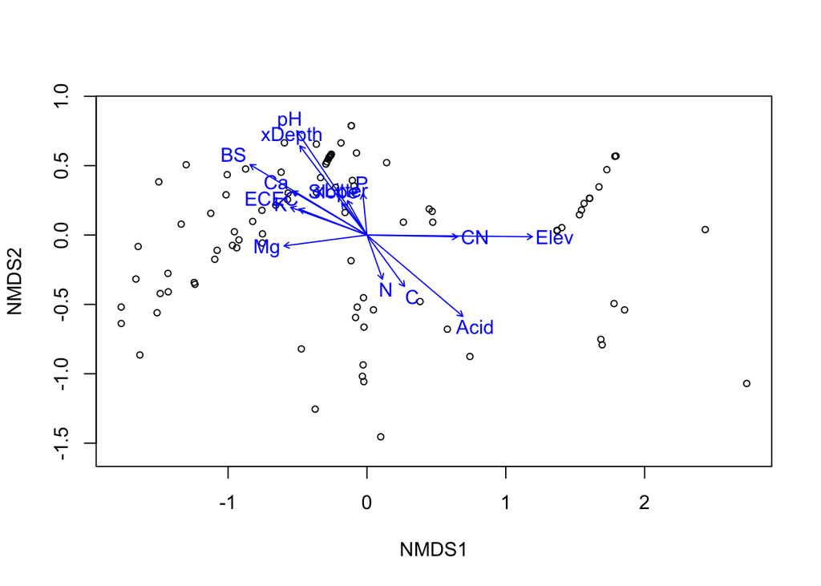

```r
plot(spp11_mds, display = 'sites')
plot(ef, p.max = 0.1)
```

```r
# TODO: highlight special sites and extract env values
```

Now choose two environment variables to create contours.

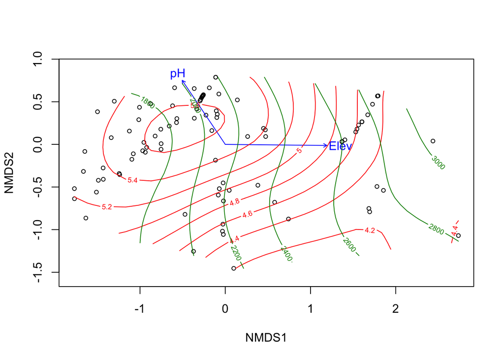

```
##
## Family: gaussian
## Link function: identity
##
## Formula:
## y ~ s(x1, x2, k = 10, bs = "tp", fx = FALSE)
## <environment: 0x7fd8533f6120>
##
## Estimated degrees of freedom:
## 8.1  total = 9.1
##
## REML score: 620.2007
```

```r
# pick two variables: pH and Elev
ef2 = envfit(spp11_mds ~ pH + Elev, env21)
plot(spp11_mds, display = 'sites')
plot(ef2)
tmp = with(env21, ordisurf(spp11_mds, pH, add=T))
with(env21, ordisurf(spp11_mds, Elev, add=T, col="green4"))
```

Get the difference in environmental values between groups (from hierarchical clustering above).

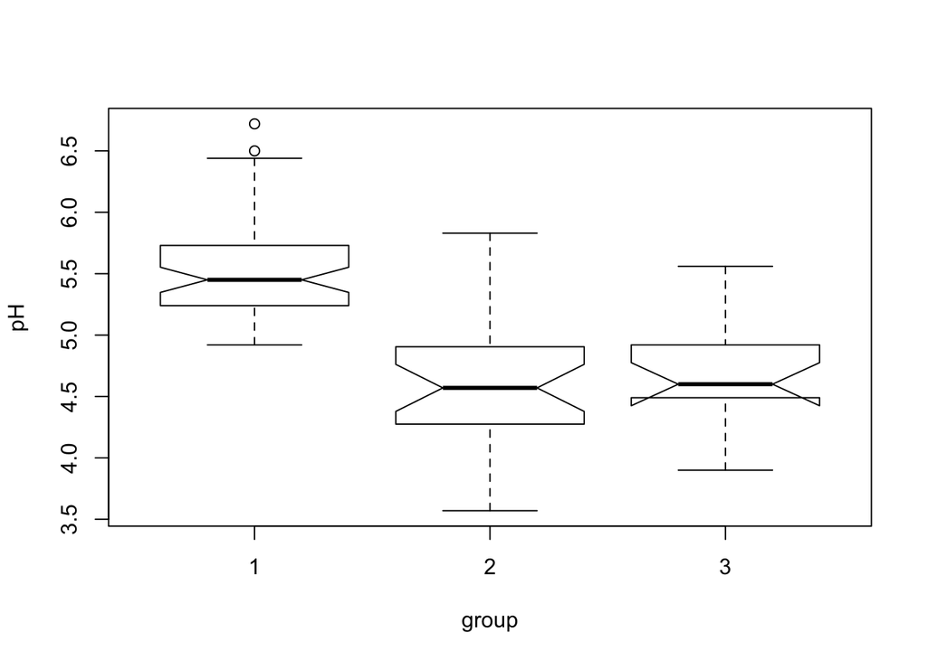

```r
boxplot(pH ~ grp, data=env21, notch = TRUE, xlab='group', ylab='pH')
```

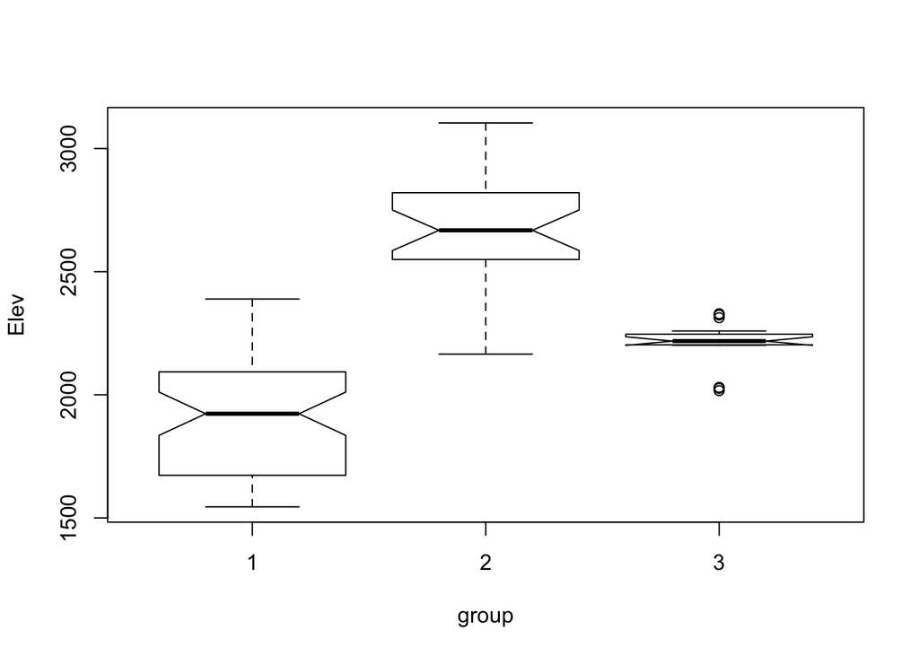

```r
boxplot(Elev ~ grp, data=env21, notch = TRUE, xlab='group', ylab='Elev')
```

# 5 Use Environment to Predict Cluster Groups

Now you’ll use recursive partitioning to see how the environmental data can be used to predict the different groups based on site species dissimmilarity.

```r
tree1 = rpart(factor(grp) ~ ., data=env21)
tree1_p = as.party(tree1)
tree1_p
```

```
##
## Model formula:
## factor(grp) ~ Elev + Slope + Tasp + TSI + xLitter + xDepth +
##     sDepth + pH + C + N + CN + P + Ca + Mg + K + Acid + ECEC +
##     BS + Clay + Silt + Sand
##
## Fitted party:
## [1] root
## |   [2] Elev < 2395
## |   |   [3] pH >= 4.845
## |   |   |   [4] Elev < 2162.5: 1 (n = 54, err = 0.0%)
## |   |   |   [5] Elev >= 2162.5: 3 (n = 8, err = 50.0%)
## |   |   [6] pH < 4.845: 3 (n = 11, err = 0.0%)
## |   [7] Elev >= 2395: 2 (n = 26, err = 0.0%)
##
## Number of inner nodes:    3
## Number of terminal nodes: 4
```

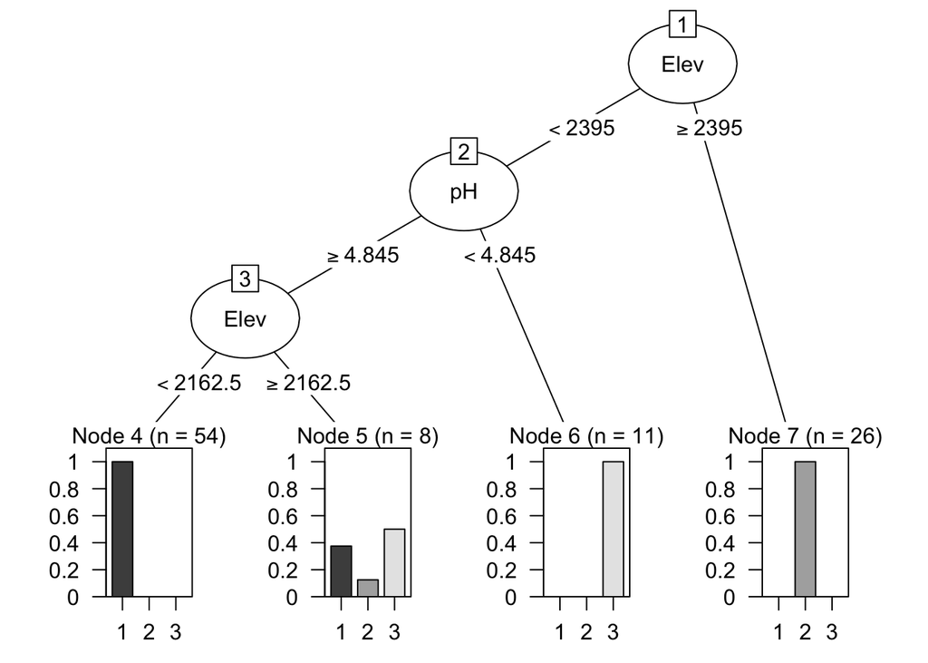

```r
plot(tree1_p)
```

# 6 Other Diversity Indices

Let’s plot some other diversity indices for each site and see how they relate to each other.

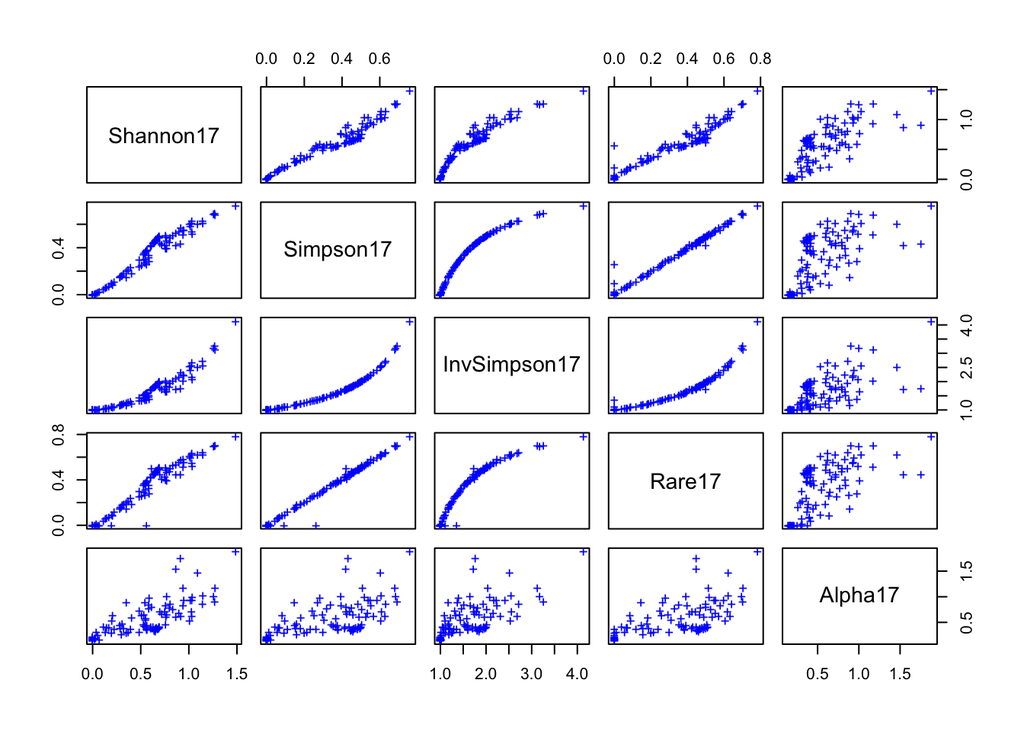

```r
# diversity indices for 17 species
Shannon17 = diversity(spp17, index='shannon')
Simpson17 = diversity(spp17, index='simpson')
InvSimpson17 = diversity(spp17, 'inv')
Rare17 = rarefy(round(spp17), 2) - 1
Alpha17 = fisher.alpha(round(spp17))
pairs(cbind(Shannon17, Simpson17, InvSimpson17, Rare17, Alpha17), pch='+', col='blue')
```

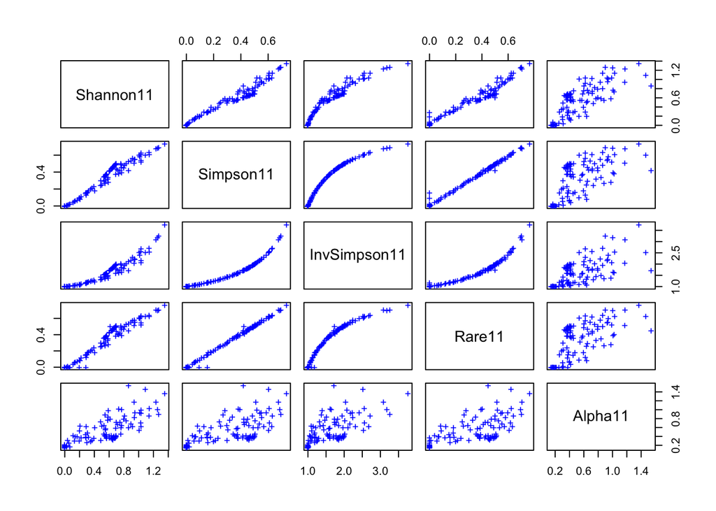

```r
# diversity indices for 17 species
Shannon11 = diversity(spp11, index='shannon')
Simpson11 = diversity(spp11, index='simpson')
InvSimpson11 = diversity(spp11, 'inv')
Rare11 = rarefy(round(spp11), 2) - 1
Alpha11 = fisher.alpha(round(spp11))
pairs(cbind(Shannon11, Simpson11, InvSimpson11, Rare11, Alpha11), pch='+', col='blue')
```

# 7 Species Accumulation Curve

Just for kicks and giggles, let’s look at species accumulation curve, or *rarefaction* curve, which shows us the number of species we expect to find as we add plots.

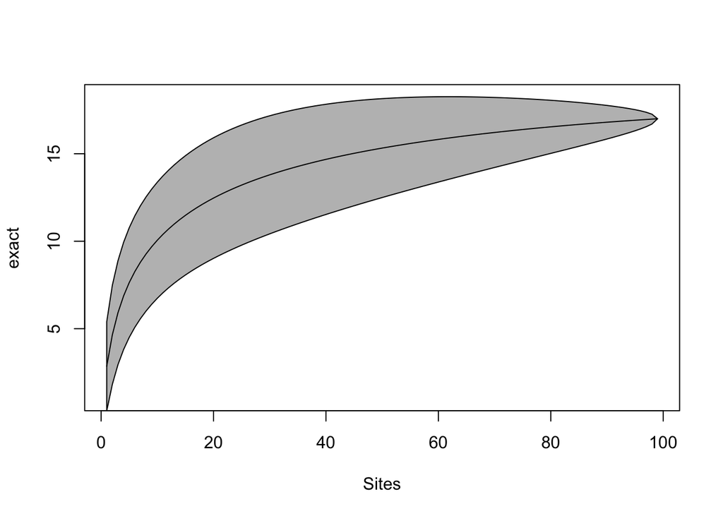

```r
# species accumulation curves
sac <- specaccum(spp17)
plot(sac, ci.type='polygon', ci.col='gray')
```

# Assignment

Besides the questions above, your assignment is to describe the species and environment associations between sites. Please reference species by “common name (code)”, such as “giant sequoia (SEgi).” Be explicit about the relationship between species and at least 3 environmental gradients as well as the 3 groups identified by the cluster analysis. You can simply refer to which sites are found in relatively high versus mid and low range environmental values. Treat this like a Results and Discussion section of a paper describing the community analysis of this Sequoia National Park study area. You might also wish to recall Figure 1.4 from the textbook (slide 18 of first lecture) by Whittaker (1956) showing the different species communities and environmental gradients of the Great Smoky Mountains.

To help you identify these differences choose Chunks -> Run All which should prompt you to click on sites (open circles). Click on sites at the environmental extremes and near the group’s center. Click ESC to exit the interactive selection of sites.

Once you’ve identified the sites, knit this document to generate the following 3 figures and 2 tables which you should include and reference by caption number in your Word document writeup. Any of the other results above you can similarly include, such as the recursive partitioning plot under “Use Environment to Predict Cluster Groups” by adding the figure, a figure number and caption.

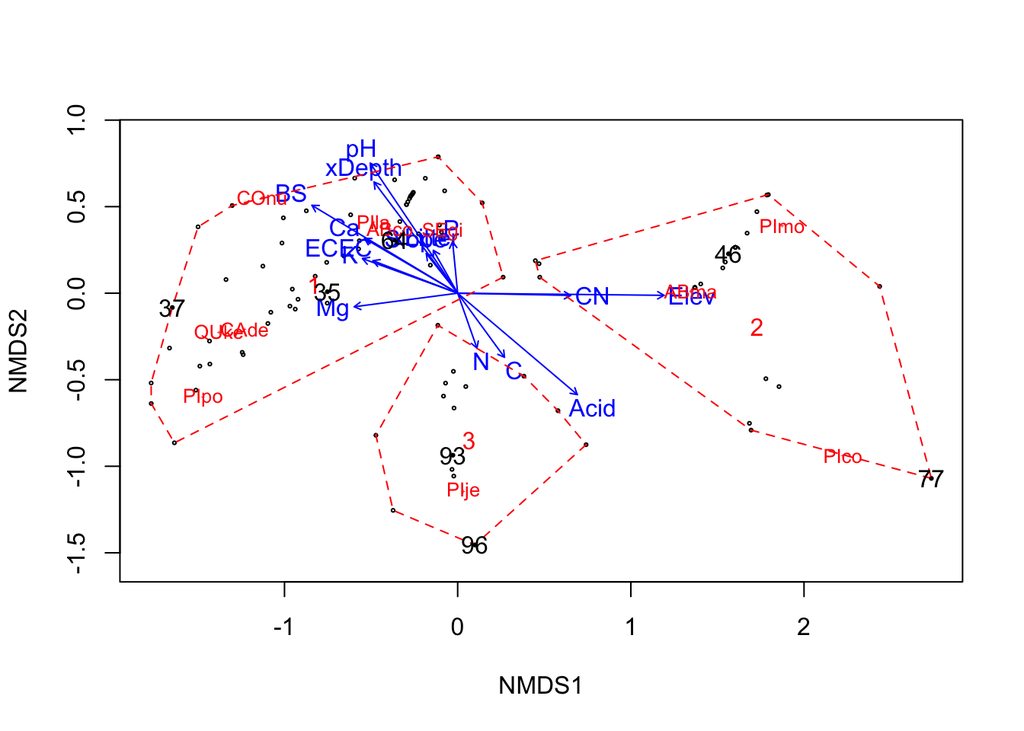

Figure 1. Sites (circles), including selected sites (closed circles with numeric id), enclosed by group membership convex hull (red dashed line; red numeric label), associated species ordination centers (red character text), and environmental gradients (blue vector lines).

Table 1. Species density (stems per hectare) original (non-normalized) values per selected site.

|  | ABco | ABma | CAde | COnu | PIco | PIje | PIla | PImo | PIpo | QUke | SEgi |
| --- | --- | --- | --- | --- | --- | --- | --- | --- | --- | --- | --- |
| 35 | 43.97 | 0.00 | 9.03 | 0 | 0.00 | 0.00 | 6.35 | 0.00 | 8.65 | 0.00 | 0.00 |
| 37 | 0.55 | 0.00 | 2.87 | 0 | 0.00 | 0.00 | 4.27 | 0.00 | 1.66 | 27.74 | 0.00 |
| 46 | 0.00 | 34.42 | 0.00 | 0 | 0.00 | 0.00 | 0.00 | 21.27 | 0.00 | 0.00 | 0.00 |
| 64 | 5.66 | 0.00 | 0.00 | 0 | 0.00 | 0.00 | 129.56 | 0.00 | 0.00 | 0.00 | 179.55 |
| 77 | 0.00 | 0.00 | 0.00 | 0 | 29.76 | 0.00 | 0.00 | 0.00 | 0.00 | 0.00 | 0.00 |
| 93 | 6.76 | 0.00 | 0.00 | 0 | 0.00 | 61.25 | 0.00 | 0.00 | 0.00 | 0.00 | 0.00 |
| 96 | 0.00 | 0.00 | 0.00 | 0 | 0.00 | 24.99 | 0.00 | 0.00 | 0.00 | 0.00 | 0.00 |

Table 2. Environmental original (non-normalized) values per selected site.

|  | Elev | Slope | Tasp | TSI | xLitter | xDepth | sDepth | pH | C | N | CN | P | Ca | Mg | K | Acid | ECEC | BS | Clay | Silt | Sand |
| --- | --- | --- | --- | --- | --- | --- | --- | --- | --- | --- | --- | --- | --- | --- | --- | --- | --- | --- | --- | --- | --- |
| 35 | 1802 | 24 | -0.15643 | 0.01871 | 6.3 | 96.52 | 11.88 | 5.56 | 3.450 | 0.130 | 26.09 | 123.23 | 7.02 | 0.817 | 0.457 | 0.077 | 8.37 | 99.07 | 0.6 | 19.1 | 80.3 |
| 37 | 1765 | 30 | -0.84805 | 0.07265 | 4.9 | 27.27 | 33.07 | 5.35 | 3.073 | 0.160 | 19.21 | 145.95 | 5.78 | 0.677 | 0.347 | 0.123 | 6.92 | 97.94 | 0.2 | 18.2 | 81.6 |
| 46 | 2687 | 17 | -0.22495 | 0.06968 | 2.7 | 54.60 | 36.30 | 4.15 | 6.373 | 0.200 | 34.20 | 76.35 | 2.01 | 0.267 | 0.397 | 2.327 | 5.00 | 54.78 | 1.6 | 29.0 | 69.3 |
| 64 | 2125 | 13 | -0.70711 | 0.00439 | 9.7 | 91.13 | 23.14 | 6.37 | 1.607 | 0.067 | 23.83 | 27.57 | 6.67 | 0.403 | 0.450 | -0.003 | 7.53 | 100.00 | 0.2 | 20.6 | 79.2 |
| 77 | 2822 | 5 | 0.60181 | 0.00436 | 2.7 | 17.30 | 10.26 | 4.27 | 2.177 | 0.090 | 24.40 | 238.43 | 0.32 | 0.067 | 0.130 | 1.060 | 1.57 | 33.27 | 0.0 | 20.5 | 79.6 |
| 93 | 2218 | 4 | -0.19082 | -0.01310 | 2.7 | 41.30 | 18.64 | 5.16 | 1.753 | 0.077 | 23.19 | 89.77 | 2.86 | 0.377 | 0.357 | 0.097 | 3.70 | 96.87 | 0.0 | 19.0 | 81.3 |
| 96 | 2017 | 10 | 0.97437 | 0.04057 | 1.3 | 4.07 | 4.87 | 3.90 | 6.330 | 0.283 | 22.27 | 81.60 | 1.56 | 0.237 | 0.200 | 2.337 | 4.33 | 46.60 | 2.1 | 22.3 | 75.6 |

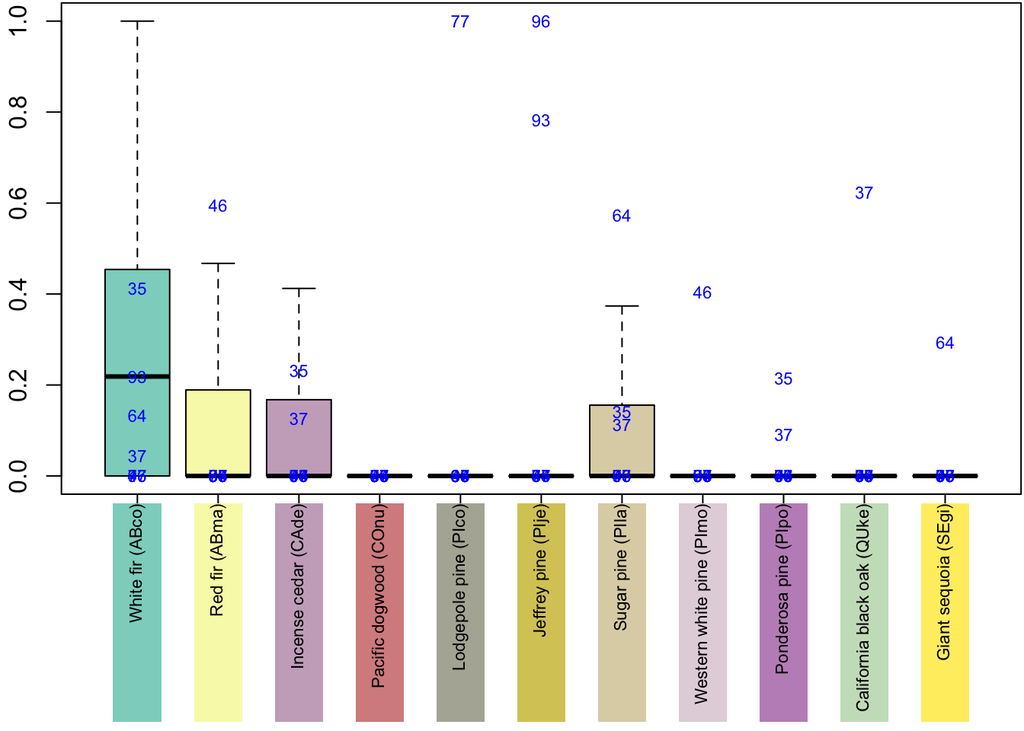

Figure 2. Normalized species densities with with selected sites shown in rank order (blue text).

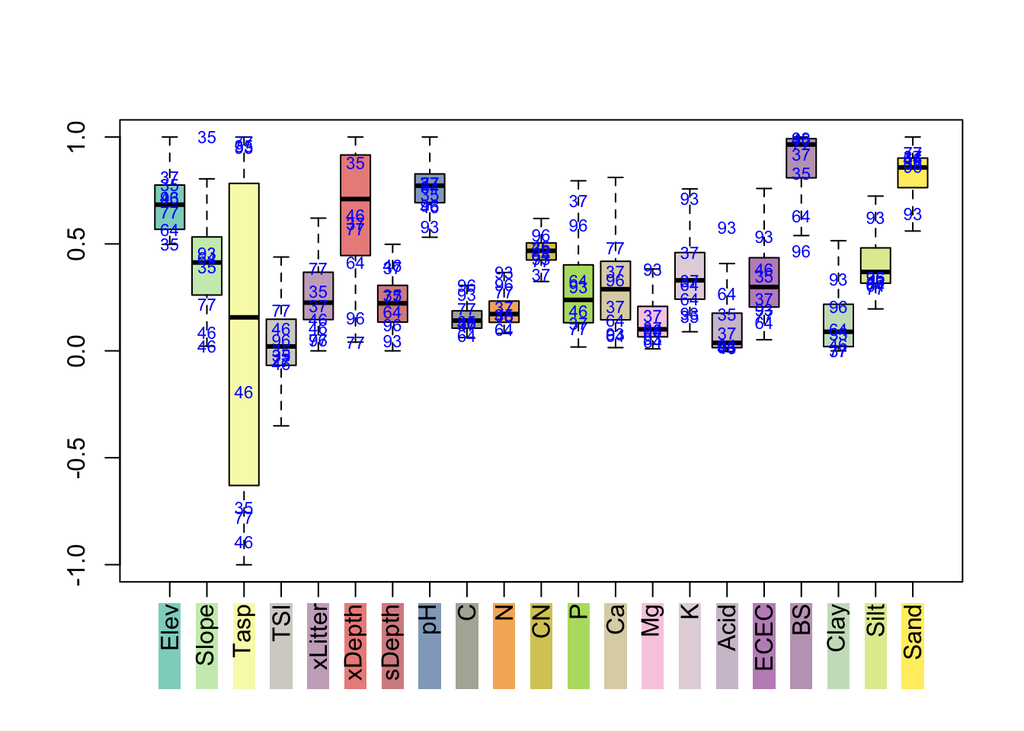

Figure 3. Normalized environmental densities with selected sites shown in rank order (blue text).

# Further Resources

The data set and overall concepts were pulled from Dean Urban’s Multivariate Analysis class at Duke University. The specific R commands have been updated to use the Vegan R package as described by these instructive vignettes:

- [Vegan tutorial](http://cc.oulu.fi/~jarioksa/opetus/metodi/vegantutor.pdf)
- [Introduction to ordination in vegan](http://cran.r-project.org/web/packages/vegan/vignettes/intro-vegan.pdf)
- [Diversity analysis in vegan](http://cran.r-project.org/web/packages/vegan/vignettes/diversity-vegan.pdf)

Other helpful lecture materials can be found here:

- [Community Analysis by Jari Oksanen](http://cc.oulu.fi/~jarioksa/opetus/metodi/)
- [R Labs for Vegetation Ecologists by Dave Roberts](http://ecology.msu.montana.edu/labdsv/R/)